# Projet - Diabète en Inde

Hugo Maury

2024-11-02

**Contexte**

Ce jeu de données provient à l’origine de l’Institut national du diabète et des maladies digestives et rénales. L’objectif de ce jeu de données est de prédire diagnostiquement si un patient a ou non le diabète, en fonction de certaines mesures diagnostiques incluses dans le jeu de données. Plusieurs contraintes ont été imposées lors de la sélection de ces instances à partir d’une base de données plus grande. En particulier, toutes les patientes ici sont des femmes d’au moins 21 ans d’origine Pima.

# 1. Présentation des données

**Pregnancies** : Nombre de fois enceinte

**Glucose** : Concentration de glucose plasmatique à 2 heures dans un test de tolérance au glucose oral

**BloodPressure** : Tension artérielle diastolique (mm Hg)

**SkinThickness** : Épaisseur du pli cutané au triceps (mm)

**Insulin** : Insuline sérique à 2 heures (mu U/ml)

**BMI** : Indice de masse corporelle (poids en kg / (taille en m)²)

**DiabetesPedigreeFunction** : Fonction de pedigree du diabète

**Age** : Âge (années)

**Outcome** : Variable de classe (0 ou 1) 268 sur 768 sont 1, les autres sont 0

*Objectif* Construire un modèle d’apprentissage automatique pour prédire avec précision si les patients du jeu de données ont ou non le diabète

# 2. Première analyse

Tableau récapitulatif

```r
### Tableau récapitulatif
tbl_summary(data, by='Outcome',
            statistic = list(all_continuous() ~ "{mean} ({median})"))
```

| **Characteristic** | **0**, N = 500<sup>1</sup> | **1**, N = 268<sup>1</sup> |
| --- | --- | --- |
| Pregnancies | 3 (2) | 5 (4) |
| Glucose | 110 (107) | 141 (140) |
| BloodPressure | 68 (70) | 71 (74) |
| SkinThickness | 20 (21) | 22 (27) |
| Insulin | 69 (39) | 100 (0) |
| BMI | 30 (30) | 35 (34) |
| DiabetesPedigreeFunction | 0.43 (0.34) | 0.55 (0.45) |
| Age | 31 (27) | 37 (36) |

<sup>1</sup> Mean (Median)

Je vois clairement quelques différences entre les patientes qui ont le diabète et ceux qui ne l’ont pas. Les patientes ayant le diabète ont géneralement 2 accouchements de plus, plus de glucose dans le sang et plus d’insuline.

Vérifions ces résultats à l’aide d’un premier modèle de régression

```r
glm(Outcome ~ ., data=data, family = binomial(link = "logit")) %>%
  tbl_regression(exponentiate = TRUE)
```

| **Characteristic** | **OR**<sup>1</sup> | **95% CI**<sup>1</sup> | **p-value** |
| --- | --- | --- | --- |
| Pregnancies | 1.13 | 1.06, 1.21 | <0.001 |
| Glucose | 1.04 | 1.03, 1.04 | <0.001 |
| BloodPressure | 0.99 | 0.98, 1.00 | 0.011 |
| SkinThickness | 1.00 | 0.99, 1.01 | >0.9 |
| Insulin | 1.00 | 1.00, 1.00 | 0.2 |
| BMI | 1.09 | 1.06, 1.13 | <0.001 |
| DiabetesPedigreeFunction | 2.57 | 1.44, 4.66 | 0.002 |
| Age | 1.01 | 1.00, 1.03 | 0.11 |

<sup>1</sup> OR = Odds Ratio, CI = Confidence Interval

Si l’on se concentre sur les p_values,je constate que l’épaisseur de la peau, l’insuline et l’âge ne semble pas avoir d’impacte pour avoir le diabète.

```r
# ---- Importation des libraries nécessaires ----
library(caret)
library(ranger)
# ---- Préparation des données ----
set.seed(42)  # Pour la reproductibilité
data$Outcome <- as.factor(data$Outcome)  # Convertir la variable cible en facteur

# Diviser les données en ensemble d'entraînement et de test
trainIndex <- createDataPartition(data$Outcome, p = .8,
                                  list = FALSE,
                                  times = 1)
dataTrain <- data[trainIndex, ]
dataTest  <- data[-trainIndex, ]

# ---- Construction du modèle avec ranger ----
rf_model <- ranger(Outcome ~ ., data = dataTrain, importance = 'impurity', num.trees = 100)

# ---- Évaluation du modèle ----
# Prédictions sur l'ensemble de test
predictions <- predict(rf_model, data = dataTest)$predictions

# Matrice de confusion
confusionMatrix(factor(predictions), dataTest$Outcome)
```

```
## Confusion Matrix and Statistics
##
##           Reference
## Prediction  0  1
##          0 80 19
##          1 20 34
##
##                Accuracy : 0.7451
##                  95% CI : (0.6684, 0.812)
##     No Information Rate : 0.6536
##     P-Value [Acc > NIR] : 0.009661
##
##                   Kappa : 0.4396
##
##  Mcnemar's Test P-Value : 1.000000
##
##             Sensitivity : 0.8000
##             Specificity : 0.6415
##          Pos Pred Value : 0.8081
##          Neg Pred Value : 0.6296
##              Prevalence : 0.6536
##          Detection Rate : 0.5229
##    Detection Prevalence : 0.6471
##       Balanced Accuracy : 0.7208
##
##        'Positive' Class : 0
##
```

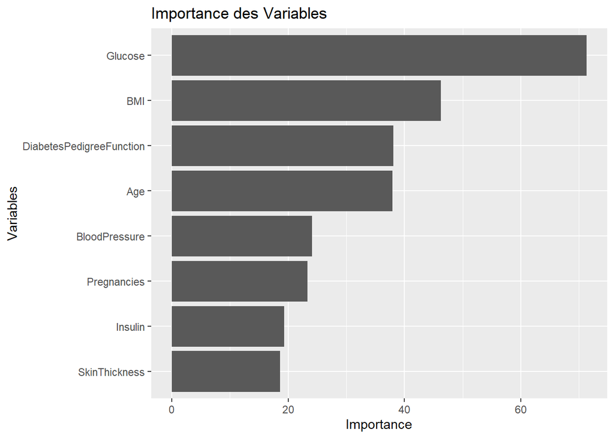

```r
# ---- Importance des variables ----
importance <- rf_model$variable.importance
importance_df <- data.frame(Variable = names(importance), Importance = importance)
importance_df <- importance_df[order(importance_df$Importance, decreasing = TRUE), ]

# Visualiser l'importance des variables
ggplot(importance_df, aes(x = reorder(Variable, Importance), y = Importance)) +
  geom_bar(stat = "identity") +
  coord_flip() +
  labs(title = "Importance des Variables", x = "Variables", y = "Importance")
```